# DRAFT: Reorienting to Recovery Habitat

DRAFT

## Baseline Habitat Inputs

Habitat inputs for the Reorienting to Recovery baseline model run include current DSMhabitat values:

Fall Run Habitat

- [`DSMhabitat::fr_spawn`](https://cvpia-osc.github.io/DSMhabitat/reference/spawn.html)
- [`DSMhabitat::fr_juv`](https://cvpia-osc.github.io/DSMhabitat/reference/juvenile.html)
- [`DSMhabitat::fr_fry`](https://cvpia-osc.github.io/DSMhabitat/reference/fry.html)
- [`DSMhabitat::fr_fp`](https://cvpia-osc.github.io/DSMhabitat/reference/floodplain.html)

Spring Run Habitat

- [`DSMhabitat::sr_spawn`](https://cvpia-osc.github.io/DSMhabitat/reference/spawn.html)
- [`DSMhabitat::sr_juv`](https://cvpia-osc.github.io/DSMhabitat/reference/juvenile.html)
- [`DSMhabitat::sr_fry`](https://cvpia-osc.github.io/DSMhabitat/reference/fry.html)
- [`DSMhabitat::sr_fp`](https://cvpia-osc.github.io/DSMhabitat/reference/floodplain.html)

Winter Run Habitat

- [`DSMhabitat::wr_spawn`](https://cvpia-osc.github.io/DSMhabitat/reference/spawn.html)
- [`DSMhabitat::wr_juv`](https://cvpia-osc.github.io/DSMhabitat/reference/juvenile.html)
- [`DSMhabitat::wr_fry`](https://cvpia-osc.github.io/DSMhabitat/reference/fry.html)
- [`DSMhabitat::wr_fp`](https://cvpia-osc.github.io/DSMhabitat/reference/floodplain.html)

Non Run Specific Habitat

- [`DSMhabitat::delta_habitat`](https://cvpia-osc.github.io/DSMhabitat/reference/delta_habitat.html)

Plus additional habitat acres from recently completed or in progress habitat restoration projects.

### Project Catalog

The Reorienting to Recovery Planning team solicited input for the project catalog (via email, office hours, and one-on-one calls) from watershed associations, CDFW staff, DWR habitat workshop group and project proponents. They consolidated project lists received from CDFW and DWR into a Project Catalog of ~250 projects.

27 of the projects in the project catalog were identified for inclusion in the baseline based on the following criteria - at least one of the rulesets below must true:

- The project has greater that 50% funding allocated to it
- Environmental permitting for the project has been applied for and/ or granted
- The project is under construction
- The project or endeavor consists of a suite of management actions (e.g. re-operation of existing infrastructure) that are actively being considered by managers, have been approved, or are newly (within the last calendar year) being implemented

#### Project Catalog Summary

FlowWest summarized the project catalog by run, tributary, and habitat type to find total acres of habitat added to each Tributary. The following table shows summarized habitat added to each tributary:

| Watershed | Habitat Type | Run | Proportion Suitable | Total Acres |
| --- | --- | --- | --- | --- |
| Upper Sacramento River | spawning | fall | 0.12 | 3.50 |
| Upper Sacramento River | inchannel rearing | fall | 0.10 | 12.10 |
| Upper-mid Sacramento River | inchannel rearing | fall | 0.78 | 1.95 |
| Lower-mid Sacramento River | floodplain rearing | fall | 0.90 | 114.00 |
| American River | spawning | fall | 0.12 | 13.00 |
| American River | inchannel rearing | fall | 0.78 | 2.00 |
| American River | inchannel rearing | fall | 0.10 | 1.00 |
| American River | floodplain rearing | fall | 0.90 | 2.00 |
| Clear Creek | spawning | fall | 0.12 | 9.50 |
| North Delta | floodplain rearing | fall | 0.90 | 5589.00 |
| Paynes Creek | spawning | fall | 0.12 | 3.00 |
| Tuolumne River | inchannel rearing | fall | 0.78 | 30.00 |
| Tuolumne River | floodplain rearing | fall | 0.90 | 90.00 |
| Yuba River | floodplain rearing | fall | 0.90 | 68.00 |
| Cottonwood Creek | spawning | spring | 0.12 | 1.00 |
| Deer Creek | spawning | spring | 0.12 | 35.33 |
| North Delta | floodplain rearing | spring | 0.90 | 5589.00 |
| Lower-mid Sacramento River | floodplain rearing | spring | 0.90 | 114.00 |
| Tuolumne River | inchannel rearing | spring | 0.78 | 30.00 |
| Tuolumne River | floodplain rearing | spring | 0.90 | 90.00 |
| Upper Sacramento River | inchannel rearing | spring | 0.78 | 7.00 |
| Upper Sacramento River | spawning | spring | 0.12 | 3.50 |
| Upper-mid Sacramento River | inchannel rearing | spring | 0.78 | 1.95 |
| Yuba River | floodplain rearing | spring | 0.90 | 68.00 |
| North Delta | floodplain rearing | winter | 0.90 | 5589.00 |
| Lower-mid Sacramento River | floodplain rearing | winter | 0.90 | 114.00 |
| Upper Sacramento River | inchannel rearing | winter | 0.78 | 199.88 |
| Upper Sacramento River | spawning | winter | 0.12 | 190.28 |
| Upper-mid Sacramento River | inchannel rearing | winter | 0.78 | 1.95 |

### Methodology for integrating habitat projects into model SIT DSM inputs

The first step was to convert total project acres into usable area given the following assumptions:

- Floodplain use 90% suitable
- In channel suitability depends on gradient ([Stillwater Sciences. 2012](http://www.ycwa-relicensing.com/Technical%20References/07%20-%20Threatened%20Endangered%20and%20Fully%20Protected%20Species/2012%20-%200221%20-%20Stillwater%20Sciences%20RIPPLE%20Report.pdf))

  | Gradient | Percent Suitable |
  | --- | --- |
  | < 0.04% | 0.1 |
  | 0 - 2 | 0.78 |
  | 2 - 4 | 0.585 |
  | 4 - 8 | 0.195 |

- Spawning use 12% suitable

Habitat values for projects were not given for specific flows. To combine project acres with existing habitat we used a scaling approach (figure 1).

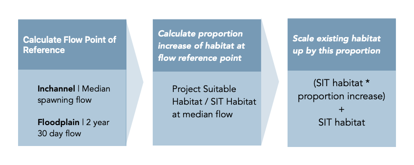

#### 1) Calculate flow point of reference

We generated two helper functions to calculate flow reference points for adding inchannel and floodplain habitat.

##### Inchannel Point of Reference

For inchannel habitat we use the median flow over the entire modeled period 1980 - 2000. Flow inputs come from CalSim II benchmark from the 2019 Itp and 2020 BiOp. `existing_cfs_median_comparison_plot` takes in `habitat_type`, `watershed`, `species`, and a `calsim_version` and returns the median flow.

Example: Median flow for American River fall run inchannel rearing

```r
existing_cfs_median_comparison_point("inchannel rearing", "American River",
                                     "fr", 'biop_itp_2018_2019')
```

```
#> [1] 2640.5
```

##### Floodplain Point of Reference

For floodplain habitat we use the 2 year 30 day exceedence value.

```r
existing_cfs_median_comparison_point("floodplain rearing", "American River",
                                     "fr", 'biop_itp_2018_2019')
```

```
#> [1] 2433.429
```

#### 2) Calculation proportion increase of habitat at flow point of reference

```r
hab_prop_change_from_projects("inchannel rearing", "American River",
                              "fr", "juv", "biop_itp_2018_2019")
```

```
#>
#> [1] 0.01211999
```

#### 3) Scale existing habitat up by proportion increase

```r
add_project_habitat <- DSMhabitat::fr_juv$biop_itp_2018_2019["American River" , , ] *
  hab_prop_change_from_projects("inchannel rearing", "American River", "fr", "juv", "biop_itp_2018_2019")
updated_habitat <- DSMhabitat::fr_juv$biop_itp_2018_2019["American River", , ] + add_project_habitat
```

### Baseline Habitat Plots

#### Spawning Habitat

Below are spawning plots displaying spawning habitat changes from CVPIA SIT habitat (blue) to baseline (red) for each run.

##### Fall Run

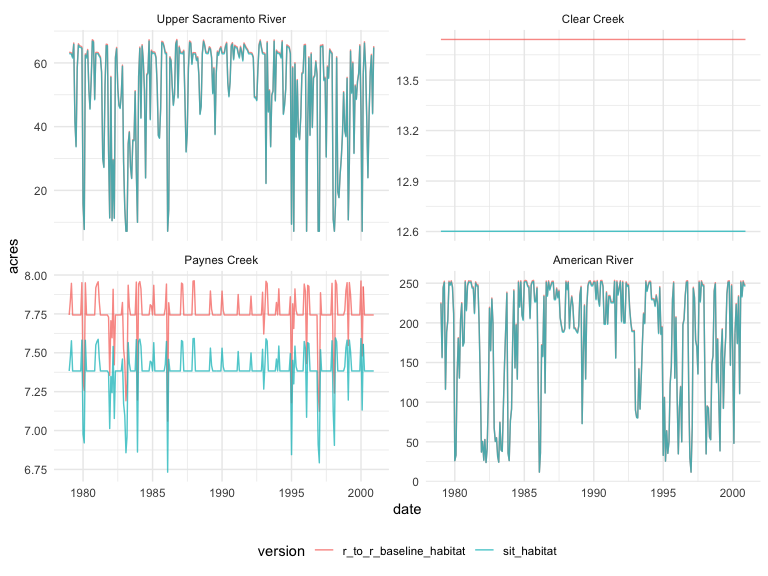

##### Spring Run

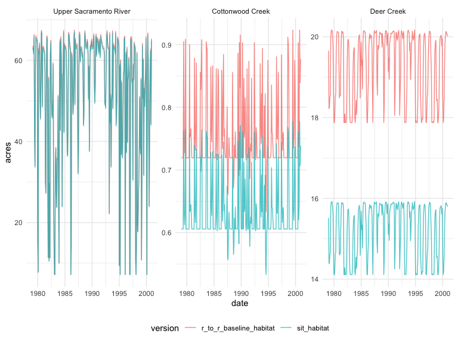

##### Winter Run

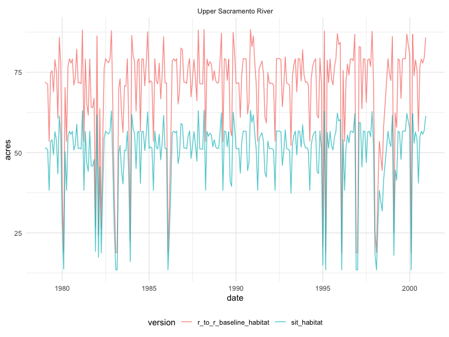

#### Inchannel Rearing Fry Habitat

Below are inchannel fry rearing plots displaying rearing habitat changes from CVPIA SIT habitat (blue) to baseline (red) for each run.

##### Fall Run

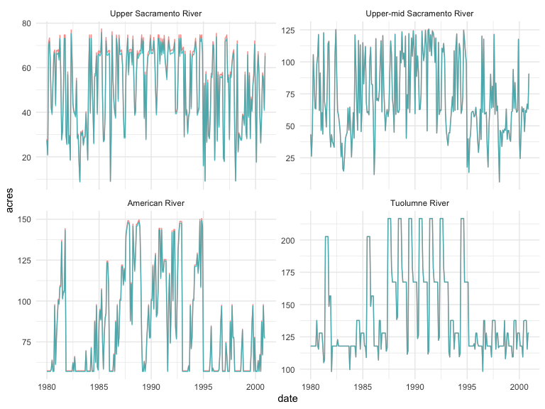

##### Spring Run

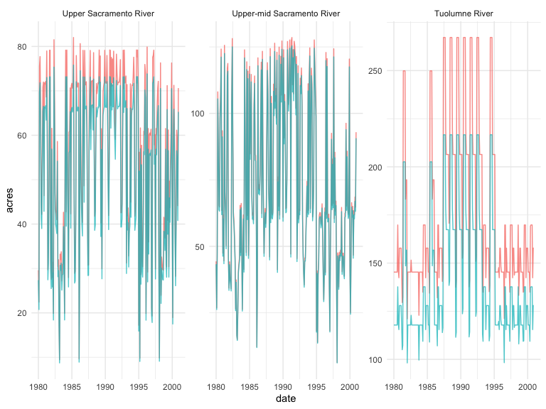

##### Winter Run

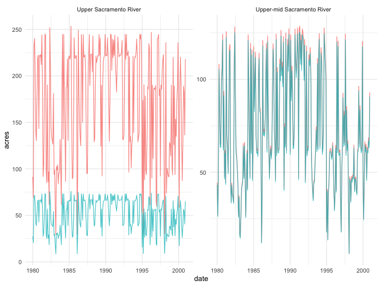

#### Inchannel Rearing Juvenile Habitat

Below are inchannel juv rearing plots displaying inchannel rearing habitat changes from CVPIA SIT habitat (blue) to baseline (red) for each run.

##### Fall Run

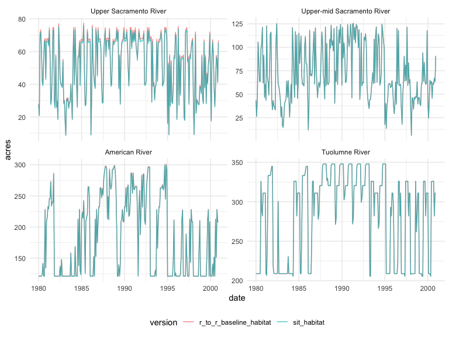

##### Spring Run

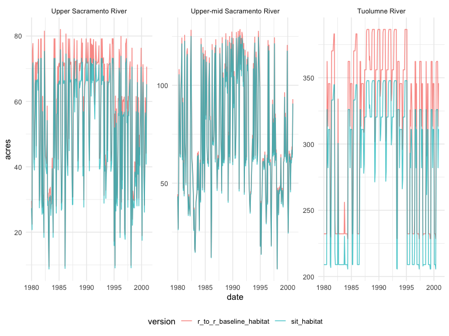

##### Winter Run

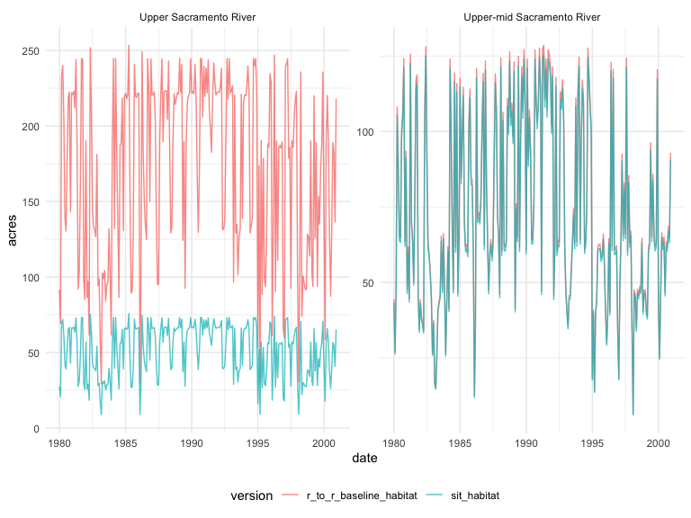

#### Floodplain Rearing Habitat

Below are floodplain rearing plots displaying floodplain rearing habitat changes from CVPIA SIT habitat (blue) to baseline (red) for each run.

##### Fall Run

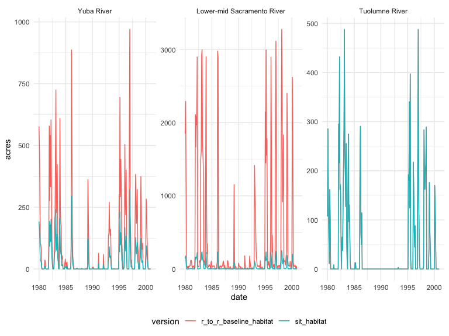

##### Spring Run

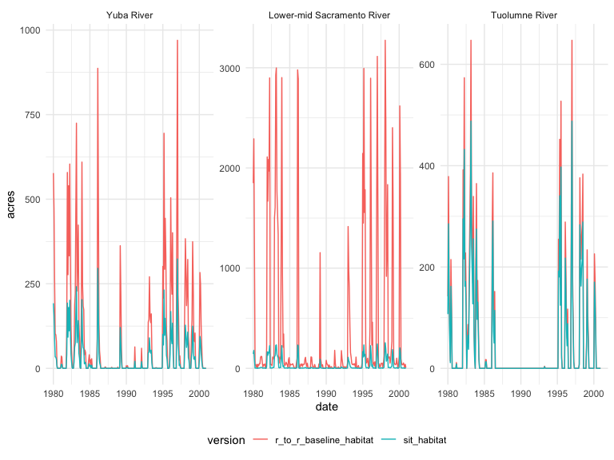

##### Winter Run

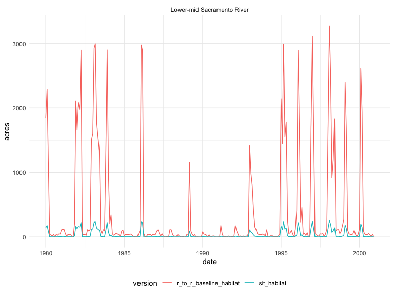

#### Delta Habitat (all runs)

Below is a delta rearing habiatat plots displaying delta rearing habitat changes from CVPIA SIT habitat (blue) to baseline (red) for each run.

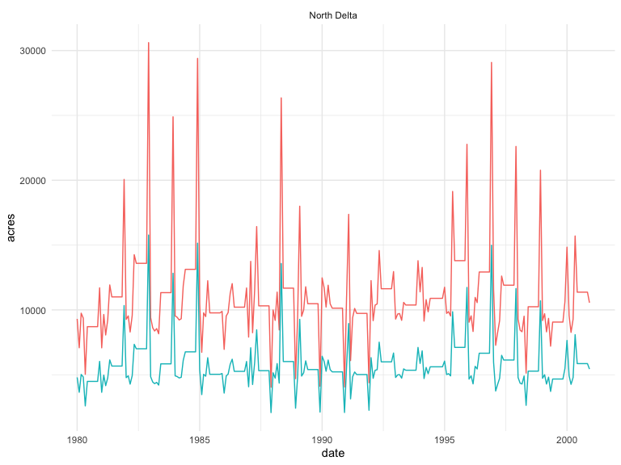